# Tutorial for time series ordinal pattern tests

## Libraries

```julia
using StatsOrdinalPatterns, Random, Statistics, DataFrames, CairoMakie
```

## Hypothesis Testing with Ordinal Patterns

An ordinal pattern test asks whether the frequencies of rank permutations in a time series are consistent with an i.i.d. (white noise) process. For a series $x_1, \ldots, x_n$, overlapping windows of length $m$ are each mapped to the permutation that describes the relative order of the values. The resulting pattern frequency distribution is summarised by a scalar test statistic. Under $H_0$ (i.i.d.) that distribution is uniform across all $m!$ patterns, so the statistic has a known or bootstrap-approximated null distribution.

## Key functions

The key functions in `StatsOrdinalPatterns.jl` for testing time series regarding dependence using ordinal patterns are:

- **Computing the statistic**
  - `stat_op(data; chart_choice, m=3, d=1)` — computes the chosen test statistic from the observed pattern frequencies.
    - Returns `[test_statistic, pattern_frequencies]`.
    - `chart_choice`: one of
      - `Persistence()`
      - `UpDownBalance()`
      - `RotationalAsymmetry()`
      - `UpDownScaling()`
      - `DistanceToWhiteNoise()`
      - [`Shannon(base=exp(1))`](https://juliadynamics.github.io/ComplexityMeasures.jl/stable/information_measures/#ComplexityMeasures.Shannon)
      - [`ShannonExtropy(base=exp(1))`](https://juliadynamics.github.io/ComplexityMeasures.jl/stable/information_measures/#ComplexityMeasures.ShannonExtropy).
    - `m`: pattern length (window size)
    - `d`: delay between observations within a window.
- **Asymptotic inference**
  - `test_op(data; chart_choice, m=3, d=1, alpha=0.05)`
    - Returns an `OPTestResult` with the test statistic, critical value, p-value, and reject decision.
    - Critical value, p-value, and rejection direction are chosen automatically from `chart_choice`.
    - `alpha`: significance level.
    - Relies on asymptotic limiting distributions; currently supports `m = 2` and `m = 3` only.
- **Bootstrap inference**
  - `bootstrap_op(data, n_boot; chart_choice, m=3, d=1, block_size=1)`
    - Returns a length-`n_boot` vector of resampled statistics under $H_0$.
    - `n_boot`: number of bootstrap replications.
    - `block_size = 1`: standard i.i.d. bootstrap. `block_size > 1`: block bootstrap that preserves local serial structure.
    - Works for any `m`.
  - `test_op_bootstrap(data, n_boot; chart_choice, m=3, d=1, alpha=0.05, block_size=1)`
    - Returns an `OPTestResultBoot` struct with the observed statistic, bootstrap critical value, bootstrap p-value, and reject decision.
    - Handles the correct bootstrap direction (two-sided, upper-tail, lower-tail) automatically.
    - `alpha`: significance level. `block_size`: as in `bootstrap_op()`.
    - Works for any `m` — the only inference option when `m > 3`.

## Available chart statistics

Seven chart statistics are available. They differ in what they measure, the direction of the rejection region, and the limiting distribution under $H_0$.

| Statistic | Constructor | Under $H_0$ | Reject $H_0$ when | Distribution |
| --- | --- | --- | --- | --- |
| Persistence ($\hat{\tau}$) | `Persistence()` | $\hat{\tau} = 0$ | $\lvert\hat{\tau}\rvert > c$ | Normal |
| UpDownBalance ($\hat{\beta}$) | `UpDownBalance()` | $\hat{\beta} = 0$ | $\lvert\hat{\beta}\rvert > c$ | Normal |
| RotationalAsymmetry ($\hat{\gamma}$) | `RotationalAsymmetry()` | $\hat{\gamma} = 0$ | $\lvert\hat{\gamma}\rvert > c$ | Normal |
| UpDownScaling ($\hat{\delta}$) | `UpDownScaling()` | $\hat{\delta} = 0$ | $\lvert\hat{\delta}\rvert > c$ | Normal |
| DistanceToWhiteNoise ($\hat{\Delta}$) | `DistanceToWhiteNoise()` | $\hat{\Delta} = 0$ | $\hat{\Delta} > c$ | Generalized $\chi^2$ |
| Shannon entropy ($\hat{H}$) | [`Shannon(base=exp(1))`](https://juliadynamics.github.io/ComplexityMeasures.jl/stable/information_measures/#ComplexityMeasures.Shannon) | $\hat{H} = \log(m!)$ | $\hat{H} < c$ | Generalized $\chi^2$ |
| Shannon extropy ($\hat{H}_\text{ex}$) | [`ShannonExtropy(base=exp(1))`](https://juliadynamics.github.io/ComplexityMeasures.jl/stable/information_measures/#ComplexityMeasures.ShannonExtropy) | $\hat{H}_\text{ex} = 5\log(6/5)$ | $\hat{H}_\text{ex} < c$ | Generalized $\chi^2$ |

- The first four statistics use a **two-sided** test. `DistanceToWhiteNoise` is always non-negative — **upper-tail**.
- The entropy statistics decrease under non-uniformity — **lower-tail**.
- The test direction determines how bootstrap p-values are computed (see below).
- The asymptotic critical values and their limiting distributions are derived in Weiß (2022).

## Logarithm base

[`Shannon`](https://juliadynamics.github.io/ComplexityMeasures.jl/stable/information_measures/#ComplexityMeasures.Shannon) and [`ShannonExtropy`](https://juliadynamics.github.io/ComplexityMeasures.jl/stable/information_measures/#ComplexityMeasures.ShannonExtropy) come from ComplexityMeasures.jl, where both use base 2 by default. The papers behind this package use the natural logarithm, and all asymptotic results are derived for it. Write [`Shannon(base=exp(1))`](https://juliadynamics.github.io/ComplexityMeasures.jl/stable/information_measures/#ComplexityMeasures.Shannon) to obtain the values reported in the papers. The Unicode form [`Shannon(base=ℯ)`](https://juliadynamics.github.io/ComplexityMeasures.jl/stable/information_measures/#ComplexityMeasures.Shannon), typed as `\euler` followed by Tab, is equivalent.

Any base larger than 1 is allowed. An entropy in base $b$ equals the entropy under the natural logarithm divided by $\ln b$. The package applies this conversion as follows.

| Quantity | With base $b$ |
| --- | --- |
| Statistic of `stat_op`, `stat_sop` and `test_op` | divided by $\ln b$ |
| Critical value of `test_op` and `crit_val_op` | divided by $\ln b$ |
| Control limit `cl` of the EWMA charts | must be given in base $b$ |
| Box-Pierce statistic and rescaled SOP statistic | unchanged |
| p-value and test decision | unchanged |

For example, the pattern frequencies $\hat{p} = (0.30, 0.20, 0.15, 0.15, 0.10, 0.10)$ give a Shannon entropy of 1.7127 under the natural logarithm, $1.7127 / \ln 2 = 2.4710$ in base 2, and $1.7127 / \ln 10 = 0.7438$ in base 10.

```julia
p = [0.30, 0.20, 0.15, 0.15, 0.10, 0.10]
[chart_stat_op(p, Shannon(base=b)) for b in (exp(1), 2, 10)]
```

```
3-element Vector{Float64}:
 1.7127324378491742
 2.4709505944546684
 0.7438302467346005
```

A base of 1 or smaller raises an error. Base 1 would divide by zero, and a base between 0 and 1 would make the entropy negative and reverse the direction of the tests.

## Setup

```julia
Random.seed!(42)
n, m, d = 300, 3, 1
n_pat = n - (m - 1) * d
```

```
298
```

## Example data

```julia
data_iid = randn(n)   # i.i.d. — H₀ is true

φ = 0.5
data_ar1 = zeros(n);
data_ar1[1] = randn();
for t in 2:n
    data_ar1[t] = φ * data_ar1[t-1] + randn()
end   # AR(1) — H₀ is false
```

## Asymptotic testing: `test_op()`

### Two-sided — Persistence

```julia
test_op(data_iid; chart_choice=Persistence(), m=m, d=d)
```

```
OPTestResult
  Chart:            Persistence()
  Statistic:        0.0157
  ─────────────────────────────
  Asymptotic test
    Critical value: 0.0479
    p-value:        0.5214
    Reject H₀:      false
```

```julia
test_op(data_ar1; chart_choice=Persistence(), m=m, d=d)
```

```
OPTestResult
  Chart:            Persistence()
  Statistic:        0.123
  ─────────────────────────────
  Asymptotic test
    Critical value: 0.0479
    p-value:        0.0
    Reject H₀:      true
```

### Upper-tail — DistanceToWhiteNoise

```julia
test_op(data_iid; chart_choice=DistanceToWhiteNoise(), m=m, d=d)
```

```
OPTestResult
  Chart:            DistanceToWhiteNoise()
  Statistic:        0.002
  ─────────────────────────────
  Asymptotic test
    Critical value: 0.005
    p-value:        0.3652
    Reject H₀:      false
```

```julia
test_op(data_ar1; chart_choice=DistanceToWhiteNoise(), m=m, d=d)
```

```
OPTestResult
  Chart:            DistanceToWhiteNoise()
  Statistic:        0.0114
  ─────────────────────────────
  Asymptotic test
    Critical value: 0.005
    p-value:        0.0011
    Reject H₀:      true
```

### Lower-tail — Shannon entropy

```julia
test_op(data_iid; chart_choice=Shannon(base=exp(1)), m=m, d=d)
```

```
OPTestResult
  Chart:            Shannon(base = 2.718281828459045)
  Statistic:        1.7859
  ─────────────────────────────
  Asymptotic test
    Critical value: 1.7768
    p-value:        0.3679
    Reject H₀:      false
```

```julia
test_op(data_ar1; chart_choice=Shannon(base=exp(1)), m=m, d=d)
```

```
OPTestResult
  Chart:            Shannon(base = 2.718281828459045)
  Statistic:        1.759
  ─────────────────────────────
  Asymptotic test
    Critical value: 1.7768
    p-value:        0.0015
    Reject H₀:      true
```

The i.i.d. series is not rejected; the AR(1) series is. The critical value is the same for both series — it depends only on `n_pat`, `m`, and `alpha`, not on the data.

## Bootstrap testing: `test_op_bootstrap()`

`test_op_bootstrap()` generates the empirical null distribution via `bootstrap_op()`, then computes the bootstrap critical value and p-value in the correct direction for the chosen statistic. It works for any `m` — including `m > 3` where `test_op()` has no asymptotic theory.

```julia
Random.seed!(42)
res_boot = test_op_bootstrap(data_ar1, 2_000; chart_choice=Persistence(), m=m, d=d)
```

```
OPTestResultBoot
  Chart:            Persistence()
  Statistic:        0.123
  ─────────────────────────────
  Bootstrap  (n_boot = 2000)
    Critical value: 0.0481
    p-value:        0.0
    Reject H₀:      true
```

The bootstrap critical value agrees closely with the asymptotic one shown above. The table below confirms this across all seven statistics.

The result keeps the resampled statistics in `res_boot.boot_dist`, and with `CairoMakie` loaded `plot` draws them as the bootstrap null distribution, with the rejection region shaded, the critical values dashed and the observed statistic as a solid line. See the plotting tutorial for the options.

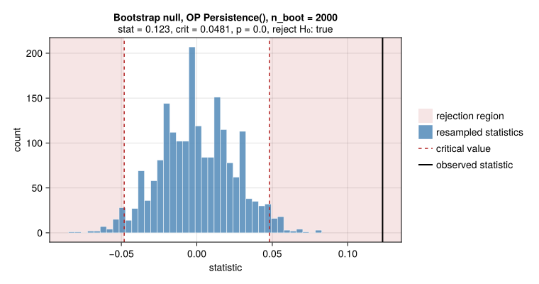

```julia
plot(res_boot)
```

## Full comparison: asymptotic vs. bootstrap

```julia
Random.seed!(42)
chart_list = [
    ("Persistence (τ)", Persistence(), "two-sided"),
    ("UpDownBalance (β)", UpDownBalance(), "two-sided"),
    ("RotationalAsymmetry (γ)", RotationalAsymmetry(), "two-sided"),
    ("UpDownScaling (δ)", UpDownScaling(), "two-sided"),
    ("DistanceToWhiteNoise (Δ)", DistanceToWhiteNoise(), "upper-tail"),
    ("Shannon entropy (H)", Shannon(base=exp(1)), "lower-tail"),
    ("Shannon extropy (Hex)", ShannonExtropy(base=exp(1)), "lower-tail"),
]
asymp_res = [test_op(data_ar1; chart_choice=c, m=m, d=d) for (_, c, _) in chart_list]
boot_res = [test_op_bootstrap(data_ar1, 2_000; chart_choice=c, m=m, d=d) for (_, c, _) in chart_list]
```

```julia
DataFrame(
    Statistic=[t[1] for t in chart_list],
    Direction=[t[3] for t in chart_list],
    stat=round.([r.stat for r in asymp_res], digits=3),
    asymp_crit=round.([r.asymp_crit for r in asymp_res], digits=3),
    asymp_pval=round.([r.asymp_pval for r in asymp_res], digits=3),
    boot_crit=round.([r.boot_crit for r in boot_res], digits=3),
    boot_pval=round.([r.boot_pval for r in boot_res], digits=3),
    reject=[r.asymp_reject for r in asymp_res],
)
```

7×8 DataFrame

| Row | Statistic String | Direction String | stat Float64 | asymp_crit Float64 | asymp_pval Float64 | boot_crit Float64 | boot_pval Float64 | reject Bool |
| --- | --- | --- | --- | --- | --- | --- | --- | --- |
| 1 | Persistence (τ) | two-sided | 0.123 | 0.048 | 0.0 | 0.048 | 0.0 | true |
| 2 | UpDownBalance (β) | two-sided | -0.007 | 0.066 | 0.841 | 0.064 | 0.882 | false |
| 3 | RotationalAsymmetry (γ) | two-sided | 0.007 | 0.072 | 0.855 | 0.074 | 0.871 | false |
| 4 | UpDownScaling (δ) | two-sided | -0.013 | 0.093 | 0.777 | 0.094 | 0.796 | false |
| 5 | DistanceToWhiteNoise (Δ) | upper-tail | 0.011 | 0.005 | 0.001 | 0.005 | 0.001 | true |
| 6 | Shannon entropy (H) | lower-tail | 1.759 | 1.777 | 0.001 | 1.777 | 0.002 | true |
| 7 | Shannon extropy (Hex) | lower-tail | 0.905 | 0.909 | 0.001 | 0.909 | 0.001 | true |

Across all seven statistics the analytical and bootstrap critical values are close, and the bootstrap p-values are consistent with the `reject` column — confirming that `bootstrap_op()` is a reliable alternative whenever the limiting distribution is complex or the sample size is small.

## References

Weiß, Christian H. 2022. “Non-Parametric Tests for Serial Dependence in Time Series Based on Asymptotic Implementations of Ordinal-Pattern Statistics.” *Chaos: An Interdisciplinary Journal of Nonlinear Science* 32 (9). https://pubs.aip.org/aip/cha/article-abstract/32/9/093107/2835852/Non-parametric-tests-for-serial-dependence-in-time?redirectedFrom=fulltext.